# Modeling and prediction for movies

Somik Chowdhury

August 30, 2018

## Setup

### Load packages

```r
library(ggplot2)
library(dplyr)
library(statsr)
```

### Load data

```r
load("~/R Coursera/movies.RData")
head(movies,1)
```

```
## # A tibble: 1 x 32
##   title    title_type  genre runtime mpaa_rating studio      thtr_rel_year
##   <chr>    <fct>       <fct>   <dbl> <fct>       <fct>               <dbl>
## 1 Filly B~ Feature Fi~ Drama      80 R           Indomina M~          2013
## # ... with 25 more variables: thtr_rel_month <dbl>, thtr_rel_day <dbl>,
## #   dvd_rel_year <dbl>, dvd_rel_month <dbl>, dvd_rel_day <dbl>,
## #   imdb_rating <dbl>, imdb_num_votes <int>, critics_rating <fct>,
## #   critics_score <dbl>, audience_rating <fct>, audience_score <dbl>,
## #   best_pic_nom <fct>, best_pic_win <fct>, best_actor_win <fct>,
## #   best_actress_win <fct>, best_dir_win <fct>, top200_box <fct>,
## #   director <chr>, actor1 <chr>, actor2 <chr>, actor3 <chr>,
## #   actor4 <chr>, actor5 <chr>, imdb_url <chr>, rt_url <chr>
```

## Part 1: Data

The data set is comprised of 651 randomly sampled movies produced and released before 2016.

Three types of ratings are available in the Dataset. one is IMDB rating which comes from IMDB and Two ratings, Critic’s rating and Audience rating have been taken from Rotten Tomatoes.

Since Random Sampling was used, correlations can be drawn on the data and the results can be generalized to all movies.

## Part 2: Research question

Is there any difference in proportion of the critics rating(Certified Fresh, Fresh, Rotten) based on the genre of a movie. Is the case different if we take audience rating into consideration instead of Critics Rating.

Is there a way to predict the Critics rating of a movie based on the audience’s review of the movie. (IMDB/AUDIENCE SCORE or both)

Being a movie buff especially in Action and Adventure Genre. It is interesting for me to see if there is a correlation between the Genre of a movie and its critical ratings.

## Part 3: Exploratory data analysis

**Numerical Summary**

```r
movies %>% group_by(genre,critics_rating,audience_rating) %>% select(genre,critics_rating,audience_rating,runtime,critics_score,audience_score) %>% summary(count=n())
```

```
##                 genre             critics_rating audience_rating
##  Drama             :305   Certified Fresh:135    Spilled:275
##  Comedy            : 87   Fresh          :209    Upright:376
##  Action & Adventure: 65   Rotten         :307
##  Mystery & Suspense: 59
##  Documentary       : 52
##  Horror            : 23
##  (Other)           : 60
##     runtime      critics_score    audience_score
##  Min.   : 39.0   Min.   :  1.00   Min.   :11.00
##  1st Qu.: 92.0   1st Qu.: 33.00   1st Qu.:46.00
##  Median :103.0   Median : 61.00   Median :65.00
##  Mean   :105.8   Mean   : 57.69   Mean   :62.36
##  3rd Qu.:115.8   3rd Qu.: 83.00   3rd Qu.:80.00
##  Max.   :267.0   Max.   :100.00   Max.   :97.00
##  NA's   :1
```

**Extrapolation**

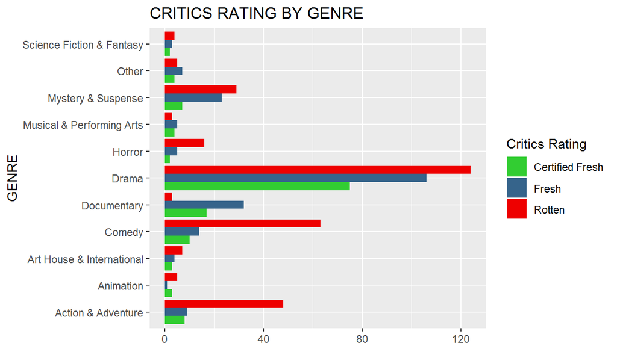

```r
ggplot(data = movies,aes(x=genre))+geom_bar(aes(fill= critics_rating),position = "dodge")+coord_flip()+scale_fill_manual("Critics Rating",values = c("Certified Fresh"="limegreen","Fresh" = "steelblue4","Rotten" = "red2"))+ylab(NULL)+xlab("GENRE")+ggtitle("CRITICS RATING BY GENRE")
```

We can clearly see that the proportion of Critics Ratings is quite different when we group the movies by their respective Genres. While there is a consistent difference in proportion of the ratings for Drama and Mystery & Suspense. Horror, Comedy and Action and Adventure have a significant difference in the proportion of ratings with a huge chunk of the movies falling under Rotten and smaller proportion falling in Fresh and Certified Fresh Criteria.

Surprisingly, Documentary movies have a majority of its numbers falling in Fresh and Certified Fresh rating and a small minority falling under the Rotten bucket.

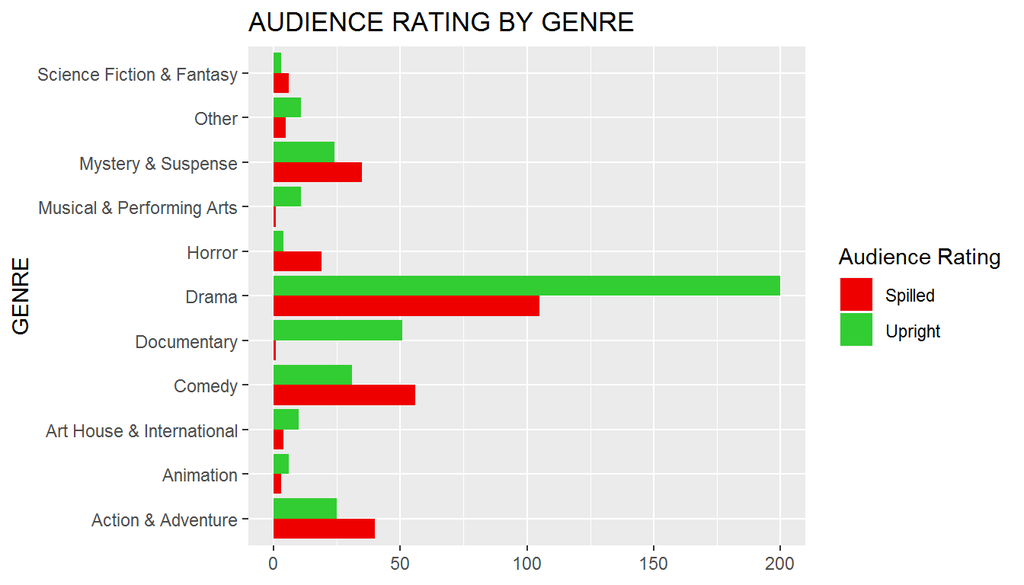

```r
ggplot(data = movies,aes(x=genre))+geom_bar(aes(fill= audience_rating),position = "dodge")+coord_flip()+scale_fill_manual("Audience Rating",values = c("Spilled"="red2","Upright" = "limegreen"))+ylab(NULL)+xlab("GENRE")+ggtitle("AUDIENCE RATING BY GENRE")
```

When compared to Critics rating. Audience Rating shows similar trends. The ratio of Upright vs Spilled rating is almost double for the Genre Drama. Action & Adventure has a consistent ratio of ratings which is different from the Critics ratings. Documentary movies have performed exceptionally well in both Audiences as well as Critics Rating with only a very small minority of them rated poorly.

We can safely conclude, that genre plays a significant role in the rating of the movie. Drama movies tend to have a consistent ratio between poor and good rating while Action & Adventure movies have a majority of Bad ratings than Good ones. The trend is similar when for Audience Ratings with the minor expceptions like Animation movies and Action & Adventure.

## Part 4: Modeling

**Research Question**

Is there a way to predict the Critics Rating of a movie based on the other variables in the data

For this analysis, I have used Backward Selection model to include the correct number of variables

```r
summary(lm(as.numeric(critics_score)~audience_score+imdb_rating+imdb_num_votes+runtime,data = movies))
```

```
##
## Call:
## lm(formula = as.numeric(critics_score) ~ audience_score + imdb_rating +
##     imdb_num_votes + runtime, data = movies)
##
## Residuals:
##     Min      1Q  Median      3Q     Max
## -72.689 -12.345   2.063  12.775  41.550
##
## Coefficients:
##                  Estimate Std. Error t value Pr(>|t|)
## (Intercept)    -6.291e+01  6.129e+00 -10.265  < 2e-16 ***
## audience_score  2.350e-01  7.059e-02   3.329 0.000922 ***
## imdb_rating     1.673e+01  1.351e+00  12.388  < 2e-16 ***
## imdb_num_votes -1.171e-05  7.026e-06  -1.667 0.096020 .
## runtime        -1.916e-02  3.991e-02  -0.480 0.631408
## ---
## Signif. codes:  0 '***' 0.001 '**' 0.01 '*' 0.05 '.' 0.1 ' ' 1
##
## Residual standard error: 18.15 on 645 degrees of freedom
##   (1 observation deleted due to missingness)
## Multiple R-squared:  0.5945, Adjusted R-squared:  0.592
## F-statistic: 236.4 on 4 and 645 DF,  p-value: < 2.2e-16
```

If we look at the p-value of runtime, we can see that it is very high as compared to the significance level of 0.05. So, we take it out of the equation.

```r
summary(lm(critics_score~audience_score+imdb_rating+imdb_num_votes,data = movies))
```

```
##
## Call:
## lm(formula = critics_score ~ audience_score + imdb_rating + imdb_num_votes,
##     data = movies)
##
## Residuals:
##     Min      1Q  Median      3Q     Max
## -73.121 -12.617   2.316  13.165  41.664
##
## Coefficients:
##                  Estimate Std. Error t value Pr(>|t|)
## (Intercept)    -6.438e+01  5.345e+00 -12.043   <2e-16 ***
## audience_score  2.385e-01  7.002e-02   3.406   0.0007 ***
## imdb_rating     1.662e+01  1.324e+00  12.552   <2e-16 ***
## imdb_num_votes -1.271e-05  6.719e-06  -1.892   0.0590 .
## ---
## Signif. codes:  0 '***' 0.001 '**' 0.01 '*' 0.05 '.' 0.1 ' ' 1
##
## Residual standard error: 18.12 on 647 degrees of freedom
## Multiple R-squared:  0.5947, Adjusted R-squared:  0.5929
## F-statistic: 316.5 on 3 and 647 DF,  p-value: < 2.2e-16
```

Similarly we can eliminate imdb_num_votes based on its p-value

```r
model<-summary(lm(critics_score~audience_score+imdb_rating,data = movies))
model$adj.r.squared
```

```
## [1] 0.5912307
```

So, we are left with two variable audience_score and imdb_rating for our linear model. We would now eliminate one of the two variables, to see if the adjusted R2 decreases or increases.

1st case : Removing Audience Score

```r
model<-summary(lm(critics_score~imdb_rating,data = movies))
model$adj.r.squared
```

```
## [1] 0.5846403
```

2nd Case : Removing IMDB rating

```r
model<-summary(lm(critics_score~audience_score,data = movies))
model$adj.r.squared
```

```
## [1] 0.4952284
```

We can see that in both cases, the adjusted R squared decreases. Hence, we can conclude that to build this model, we should use both of these variables to calculate the values of critics rating

**Linear Model Plot**

[figure not shown]

```r
ggplot(data=movies,aes(y=critics_score,x=audience_score+imdb_rating))+geom_point()+stat_smooth(method="lm")+xlab("Audience Score and IMDB Rating")+ylab("Critics Score")
```

The plot clearly shows a linear relationship between the critics score and the Audience Score plus the IMDB Rating of a movie

**Residuals Plot**

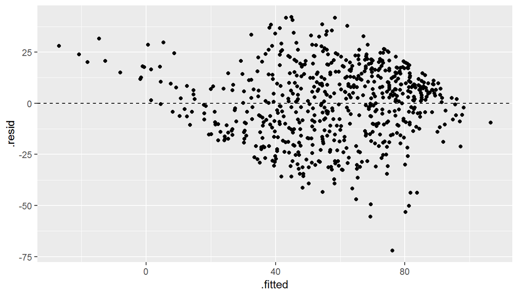

```r
model<-lm(critics_score~audience_score+imdb_rating,data = movies)
ggplot(data=model,aes(y=.resid,x=.fitted))+geom_jitter()+geom_hline(yintercept = 0,linetype="dashed")
```

In the previous EDA plots, we had seen that Genre also plays a significant part in a movies Critic’s score. So, I have decided to use Genre as one of the predictor variables to calculate the Critics score.

```r
model<-lm(critics_score~audience_score+imdb_rating+genre,data = movies)
summary(model)$adj.r.squared
```

```
## [1] 0.5980058
```

You can see that the Adjusted R Squared has increased from 0.5912307 to 0.5980058.

So final Variables used:

**audience_score**

imdb_rating

genre

## Part 5: Prediction

Being an Action Movies fan especially in the superhero genre, I would like to predict the Critics Score for the movie “Avengers : Infinity War” using my linear model.

Movie Name - Avengers : Infinity War

Release Year - 2018

IMDB Rating - 8.6

Rotten Tomatoes Audience Score - 91 (Percent)

Sources - www.imdb.com/title/tt4154756/ www.rottentomatoes.com/avengers_infinity_war/

```r
pred<-data.frame(imdb_rating = 8.6,audience_score=91,genre="Action & Adventure") #Inserting IMDB rating = 8.6 and Audience Score of 91 on Rotten tomatoes into a dataframe and the genre = Action & Adventure
predict(model,pred,interval = "prediction")
```

```
##        fit     lwr     upr
## 1 90.16756 54.3221 126.013
```

The model predicts that the movie “Avengers: Infinity War” would get a critics score of **90**. Based on the prediction interval, we would expect that there is a 95% chance that the Critic’s score would fall in the range **54% to 100%**(Since 100 is the highest rotten tomatoes score and cannot be 126).

**Comparison with actual**

As of 29th August 2018, the Critics score for “Avengers : Infinity War” is 83% which is really close to our actual prediction of 90%. 83% score correctly falls in the prediction interval(54%-100%) that my model calculated.

## Part 6: Conclusion

Based on the results, we can conclude the following

1. Genre is an important factor when it comes to the rating of a movie with Documentary movies having an exceptional Ratio of Good/Bad rating.What this means is that if today, a documentary movie is released, there is a very high chance of it being a very good movie as compared to movies of other genres.
2. Audience and Critics score show similar trends.
3. Using this model, we can predict the Critics score given the IMDB rating, the Audience score on Rotten Tomatoes and the genre of the movie.

One shortcoming of this analysis and the data set is that it does not take into account the people who cannot rate the movies. For example, a good chunk of kids watch comedy, animation and action & adventure movies with their parents(and maybe enjoy it).However, most of them do not go online to rate the movie which might slightly skew the results for these genres.